# Predict survival on the Titanic

#### Import Training and Test dataset

```r
titanic.train <- read.csv("train.csv")
titanic.test <- read.csv(("test.csv"))
```

```r
test <- titanic.test
test$Survived <- NA
test1 <- test %>% select(PassengerId,Survived,Pclass:Embarked)
titanic.full <- rbind(titanic.train,test1)
rm(test1)
rm(test)
```

#### Explore and prepare data for analysis

```r
summary(titanic.full)
```

```
  PassengerId      Survived          Pclass
 Min.   :   1   Min.   :0.0000   Min.   :1.000
 1st Qu.: 328   1st Qu.:0.0000   1st Qu.:2.000
 Median : 655   Median :0.0000   Median :3.000
 Mean   : 655   Mean   :0.3838   Mean   :2.295
 3rd Qu.: 982   3rd Qu.:1.0000   3rd Qu.:3.000
 Max.   :1309   Max.   :1.0000   Max.   :3.000
                NA's   :418
                               Name          Sex           Age
 Connolly, Miss. Kate            :   2   female:466   Min.   : 0.17
 Kelly, Mr. James                :   2   male  :843   1st Qu.:21.00
 Abbing, Mr. Anthony             :   1                Median :28.00
 Abbott, Mr. Rossmore Edward     :   1                Mean   :29.88
 Abbott, Mrs. Stanton (Rosa Hunt):   1                3rd Qu.:39.00
 Abelson, Mr. Samuel             :   1                Max.   :80.00
 (Other)                         :1301                NA's   :263
     SibSp            Parch            Ticket          Fare
 Min.   :0.0000   Min.   :0.000   CA. 2343:  11   Min.   :  0.000
 1st Qu.:0.0000   1st Qu.:0.000   1601    :   8   1st Qu.:  7.896
 Median :0.0000   Median :0.000   CA 2144 :   8   Median : 14.454
 Mean   :0.4989   Mean   :0.385   3101295 :   7   Mean   : 33.295
 3rd Qu.:1.0000   3rd Qu.:0.000   347077  :   7   3rd Qu.: 31.275
 Max.   :8.0000   Max.   :9.000   347082  :   7   Max.   :512.329
                                  (Other) :1261   NA's   :1
             Cabin      Embarked
                :1014    :  2
 C23 C25 C27    :   6   C:270
 B57 B59 B63 B66:   5   Q:123
 G6             :   5   S:914
 B96 B98        :   4
 C22 C26        :   4
 (Other)        : 271
```

*Replace NA with mean value for fare*

```r
titanic.full$Fare <- ifelse(is.na(titanic.full$Fare),
                            mean(titanic.full$Fare,na.rm = TRUE),
                            titanic.full$Fare)
```

*Replacing Age Missing value with the median Age*

```r
titanic.full$Age <- ifelse(
  is.na(titanic.full$Age),
  median(titanic.full$Age,na.rm = TRUE),
  titanic.full$Age
  )
```

*Adding Family Indicator and Cabin Type*

```r
titanic.full$SibSp <- ifelse(titanic.full$SibSp > 0, 1,0)
titanic.full$Parch <- ifelse(titanic.full$Parch > 0, 1,0)
titanic.full$Family <- ifelse((titanic.full$Parch + titanic.full$SibSp) > 0,1,0)
titanic.full <- subset(titanic.full,select = -c(SibSp,Parch,Name))
titanic.full$Cabin <-substr(titanic.full$Cabin,1,1)
titanic.full$Cabin <-ifelse(titanic.full$Cabin =='',"X",titanic.full$Cabin)  # No Cabin (X)
titanic.full$Embarked <-as.factor(ifelse(as.character(titanic.full$Embarked) =="","S",as.character(titanic.full$Embarked)))
```

*Move data back to training and test set*

```r
titanic.train.clean <- titanic.full[1:891,]
titanic.test.clean <- titanic.full[892:1309,]
titanic.test.clean <- titanic.test.clean[,!(names(titanic.test.clean) %in% c("Survived"))]
```

#### Exploratory Data Analysis and Plots

*Servived passanger proportion*

```r
round(prop.table(table(titanic.train.clean$Survived)),2) # 38% servived
```

```
   0    1
0.62 0.38
```

*Gender wise passanger proportion*

```r
round(prop.table(table(titanic.train.clean$Sex)),2)  # 35/65
```

```
female   male
  0.35   0.65
```

```r
round(prop.table(table(titanic.train.clean$Survived,titanic.train.clean$Sex)),2)
```

```
    female male
  0   0.09 0.53
  1   0.26 0.12
```

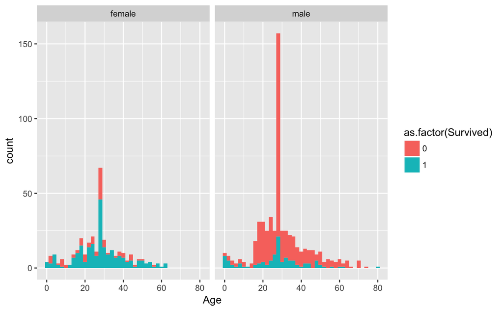

```r
library(ggplot2)
ggplot(data = titanic.train.clean,aes(x = Age)) +
  geom_histogram(aes(fill = as.factor(Survived)),binwidth = 2) +
  facet_wrap(~ Sex)
```

Female of all age was able to survived better, male did not made it.

*PClass wise passanger proportion*

```r
round(prop.table(table(titanic.train.clean$Pclass)),2)
```

```
   1    2    3
0.24 0.21 0.55
```

```r
round(prop.table(table(titanic.train.clean$Survived,titanic.train.clean$Pclass)),2)
```

```
       1    2    3
  0 0.09 0.11 0.42
  1 0.15 0.10 0.13
```

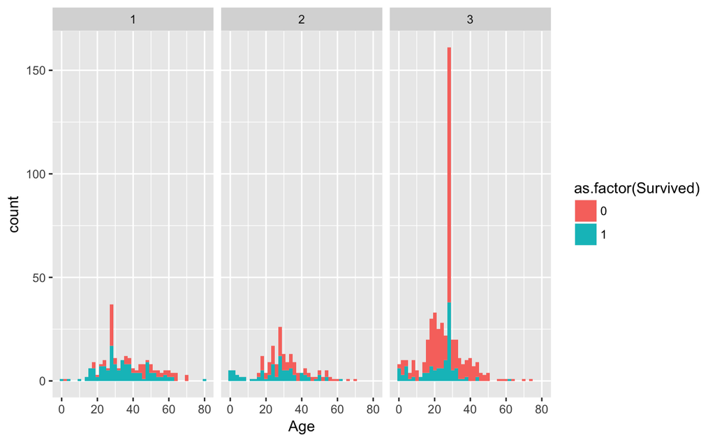

```r
ggplot(data = titanic.train.clean,aes(x = Age)) +
  geom_histogram(aes(fill = as.factor(Survived)),binwidth = 2) +
  facet_wrap(~ Pclass)
```

Plot indicates PClass -1 pasanger survival was better among other PClasses. Survival chance in Pclass 2 was 50%. There was only 13% passengers survivived in PClass 3 even through this class covering the 55% passengers.

*Cabin wise passanger proportion*

```r
round(prop.table(table(titanic.train.clean$Cabin)),2)
```

```
   A    B    C    D    E    F    G    T    X
0.02 0.05 0.07 0.04 0.04 0.01 0.00 0.00 0.77
```

```r
round(prop.table(table(titanic.train.clean$Survived,titanic.train.clean$Cabin)),2)
```

```
       A    B    C    D    E    F    G    T    X
  0 0.01 0.01 0.03 0.01 0.01 0.01 0.00 0.00 0.54
  1 0.01 0.04 0.04 0.03 0.03 0.01 0.00 0.00 0.23
```

Survival percent of passangers in cabin B,C,D,E is better compared to A and F. Cabin X which is default cabin affected most.

*Embarked wise passanger proportion*

```r
round(prop.table(table(titanic.train.clean$Embarked)),2)
```

```
   C    Q    S
0.19 0.09 0.73
```

```r
round(prop.table(table(titanic.train.clean$Survived,titanic.train.clean$Embarked)),2)
```

```
       C    Q    S
  0 0.08 0.05 0.48
  1 0.10 0.03 0.25
```

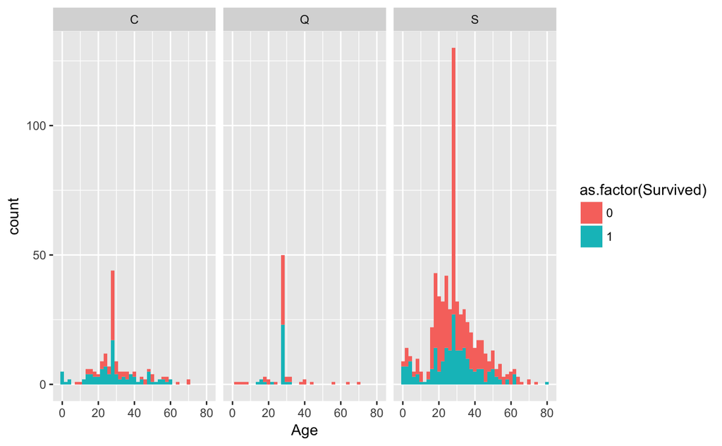

```r
ggplot(data = titanic.train.clean,aes(x = Age)) +
  geom_histogram(aes(fill = as.factor(Survived)),binwidth = 2) +
  facet_wrap(~ Embarked)
```

Passangers from Embarked S is affected most.

*Family wise passanger proportion*

```r
round(prop.table(table(titanic.train.clean$Family)),2)
```

```
  0   1
0.6 0.4
```

```r
round(prop.table(table(titanic.train.clean$Survived,titanic.train.clean$Family)),2)
```

```
       0    1
  0 0.42 0.20
  1 0.18 0.20
```

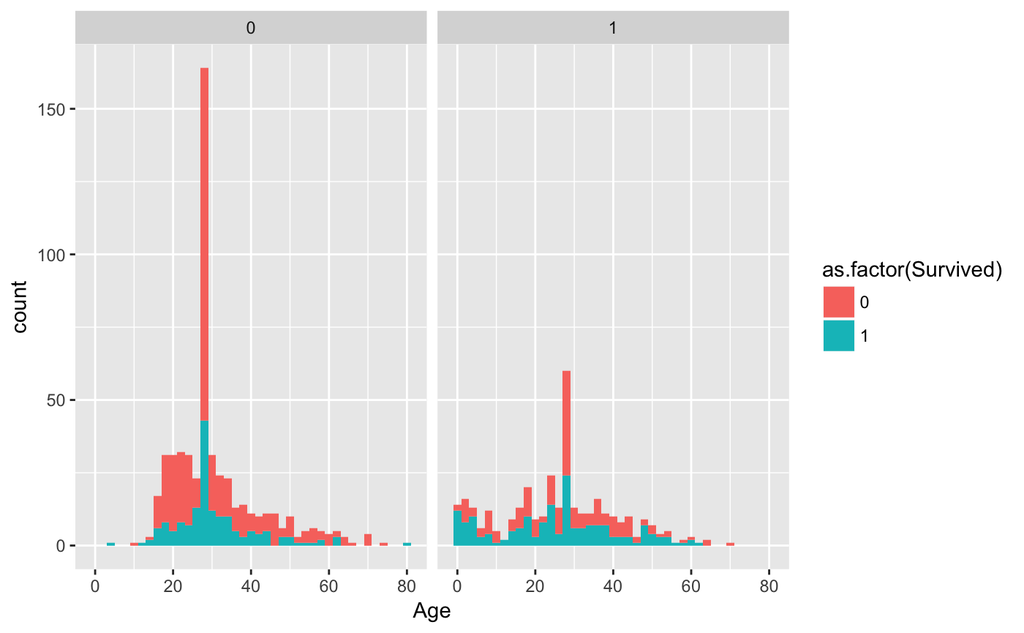

```r
ggplot(data = titanic.train.clean,aes(x = Age)) +
  geom_histogram(aes(fill = as.factor(Survived)),binwidth = 2) +
  facet_wrap(~ Family)
```

Passanger who was travelling in family was survived better.

#### Divide data in training set and test set (730/161)

*Purpose to divide the training dataset to measure the efficiency of the model

```r
set.seed(2017)
library(rpart)
train.sample <- sample(891,730)
train.set <- titanic.train.clean[train.sample,]
test.set <- titanic.train.clean[-train.sample,]
```

#### Train a decision tree model on the data

```r
train.model <- rpart(Survived ~ Pclass + Sex + Age + Family + Fare + Embarked +Cabin,                        data = train.set,
                       method = "class",
                       control = rpart.control(minsplit = 50, cp = 0))
```

#### Plot Decision Tree Model

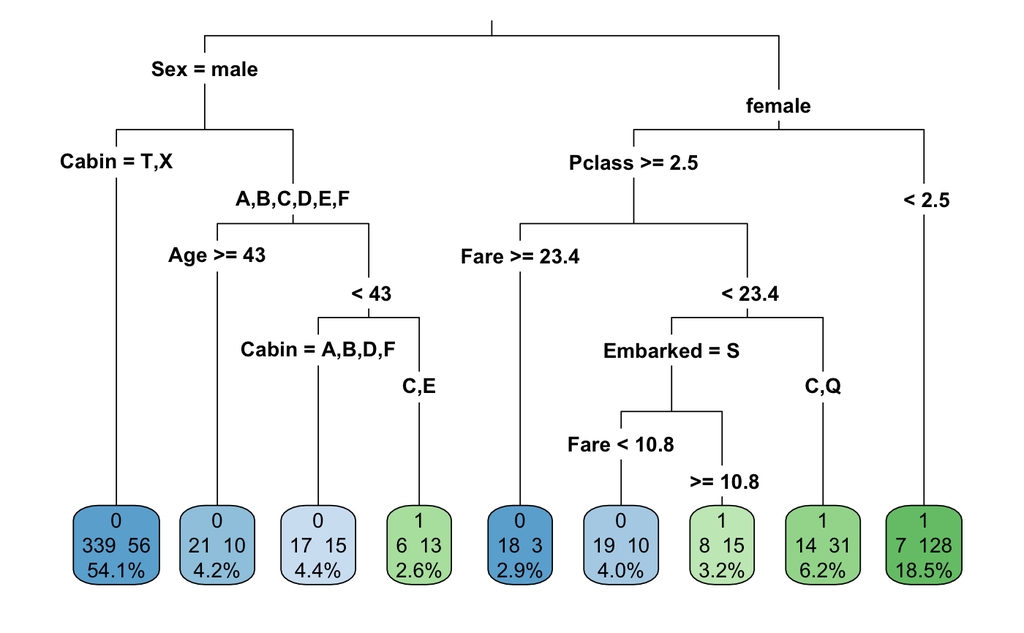

```r
library(rpart.plot)
rpart.plot(train.model,digits = 3,fallen.leaves = TRUE,type = 3,extra = 101)
```

#### Evaluate Model Performance

```r
#test.set <- subset(test.set,select = c(-Survived))
pred.survived <- predict(train.model, newdata = test.set,type = "class")
```

```r
library(gmodels)
CrossTable(test.set$Survived,
           pred.survived,
           chisq = FALSE,
           prop.c = FALSE,
           prop.r = FALSE,
           dnn = c("Actual Value","Predicted Value"))
```

```
   Cell Contents
|-------------------------|
|                       N |
| Chi-square contribution |
|         N / Table Total |
|-------------------------|


Total Observations in Table:  161


             | Predicted Value
Actual Value |         0 |         1 | Row Total |
-------------|-----------|-----------|-----------|
           0 |        88 |        12 |       100 |
             |     7.959 |    14.923 |           |
             |     0.547 |     0.075 |           |
-------------|-----------|-----------|-----------|
           1 |        17 |        44 |        61 |
             |    13.047 |    24.463 |           |
             |     0.106 |     0.273 |           |
-------------|-----------|-----------|-----------|
Column Total |       105 |        56 |       161 |
-------------|-----------|-----------|-----------|
```

Efficiency of the model = `(88+44)/161`

#### Result Prediction and saving output to a file

```r
pred <- predict(train.model, newdata = titanic.test.clean, type = "class")
```

*Save Result*

```r
solution <- data.frame(PassengerId = titanic.test.clean$PassengerId,
                       Survived = pred)
write.csv(file = "solution.csv", x= solution)
```

**remove used variables**

```r
rm(list=ls())
gc()
```

```
          used (Mb) gc trigger (Mb) max used (Mb)
Ncells 1144787 61.2    1770749 94.6  1770749 94.6
Vcells 2392745 18.3    4464987 34.1  3654156 27.9
```